# Lecture 3: R basics

EC7412 Part II: Data Science for Economists

Adam Altmejd Selder

adam.altmejd@sofi.su.se

Swedish Institute for Social Research (SOFI)

April 16, 2025

# Introduction

- Introduction
- Basic R syntax
- When things don’t work
- Logic
- Subsetting
- Scoping
- Iteration

## *Why* manipulate data with code?

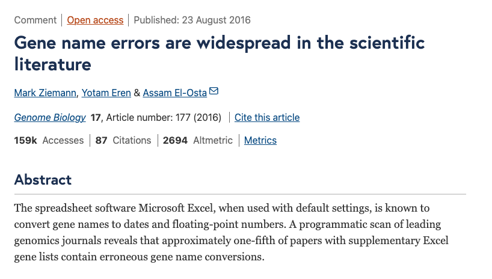

## Today

- R programming from fundamentals
- Much of what you will learn applies to all programming

## R fundamentals

- “Everything is and object and everything has a name”
  - You can access and modify everything you interact with
- You call functions to operate on objects

## Useful to know when coming from Stata

- Not limited to one dataset in memory
- Stata commands = R functions
- Less “hand-holding” when it comes to statistical analyses, need to be more mindful about what you do
- Much more dependent on external packages
  - Huge catalogue of user-created packages
  - The problem with open source: some packages are outdated or abandoned
  - You will need to learn to search for, install and load packages

## Coding environment recap

- Make sure you have `R` and `VS Code` installed
- You will also need the `VS Code R extension`
- Open a VS Code R terminal now
- Let’s make sure it works for all of you before we continue

# Basic R syntax

- Introduction
- Basic R syntax
- When things don’t work
- Logic
- Subsetting
- Scoping
- Iteration

## Operations

We can use R for arithmetic by executing operations in an R terminal:

```r
12 + 3
```

```
[1] 15
```

```r
8 - 33
```

```
[1] -25
```

```r
20 / 3
```

```
[1] 6.666667
```

```r
10 ^(2 + 1) - 1
```

```
[1] 999
```

Each row calls arithmetic *functions* on scalar *objects* (numbers).

## Running code

Options:

- Manually enter code into terminal
- `Ctrl/cmd+enter` to send row to terminal in VS Code
- Run whole R-script file (`.R`) with `Ctrl/cmd+shift+S`

## Assignment

We create new objects by assigning values to names:

```r
a <- 3
b = 5
```

Creates two scalars and assign them the names `"a"` and `"b"`.

- You can use both `<-` and `=` for assignment in R.
- Almost everyone uses `<-`, but it has some issues. For example:

```r
a < -5
a <- 5
```

## Objects

- `typeof()` tells us how objects are stored in memory
- Data will usually be stored in one of 4 types:

```r
typeof(1.0)
```

```
[1] "double"
```

```r
typeof(1L)
```

```
[1] "integer"
```

```r
typeof(TRUE)
```

```
[1] "logical"
```

```r
typeof("text")
```

```
[1] "character"
```

- But sometimes, object `class()` is more informative:

```r
typeof(mean)
```

```
[1] "closure"
```

```r
class(mean)
```

```
[1] "function"
```

## Factors

Factors are a special type that stores character vectors as integers. Each factor level is linked to a label. Good for memory efficiency and readability. Similar to how value labels work in Stata.

```r
a <- c("foo", "bar")
typeof(a)
```

```
[1] "character"
```

```r
str(factor(a))
```

```
 Factor w/ 2 levels "bar","foo": 2 1
```

```r
typeof(factor(a))
```

```
[1] "integer"
```

```r
class(factor(a))
```

```
[1] "factor"
```

## Labelling factors

Raw data often comes encoded. For example, SCB delivers the variable `Kon` (sex) which can take values `1` and `2`

```r
kon <- c(1,2)
```

We can use factors to label the values to make it easier to use:

```r
factor(kon, levels = c(1, 2), labels = c("Man", "Woman"))
```

```
[1] Man   Woman
Levels: Man Woman
```

## Naming

- A name must start with a **letter** and can contain letters, numbers, underscores, and periods.

```r
1a = 1
```

```
Error in parse(text = input): <text>:1:2: unexpected symbol
1: 1a
     ^
```

- Some names are [reserved](https://stat.ethz.ch/R-manual/R-devel/library/base/html/Reserved.html):

```r
function = 1
```

```
Error in parse(text = input): <text>:1:10: unexpected '='
1: function =
             ^
```

- Names are case sensitive!
- No length limit: `household_income_after_tax` is much better than `hhinc2`.

## Vectors and lists

```r
c(1,2,3)
```

```
[1] 1 2 3
```

Elements of `vectors` need to be of same type, or they will be coerced:

```r
c(1,2,"3")
```

```
[1] "1" "2" "3"
```

`Lists` are collections of arbitrary types:

```r
list(2,"3")
```

```
[[1]]
[1] 2

[[2]]
[1] "3"
```

## Missing values

- Each type has a “missing value” indicator `NA` (not available)

```r
c(1,NA,-1) > 0
```

```
[1]  TRUE    NA FALSE
```

- For numbers, there is also `Inf`, `-Inf` and `NaN` (not a number)

```r
1/0
```

```
[1] Inf
```

```r
0/0
```

```
[1] NaN
```

```r
is.na(c(NA, NaN))
```

```
[1] TRUE TRUE
```

```r
is.nan(c(NA, NaN))
```

```
[1] FALSE  TRUE
```

This is different from Stata where missing values are treated as infinitely large.

## Data frames

Data frames are collections (lists really) of vectors of the same length, organized in a table:

```r
df = data.frame(x = c(1,2,3),
                y = c(4,5,6))
df
```

```
  x y
1 1 4
2 2 5
3 3 6
```

Processing data in R, you will run most of your operations on `data.frames` (or similar objects like `tibbles` or `data.tables`).

```r
df^2
```

```
  x  y
1 1 16
2 4 25
3 9 36
```

## Functions

- Like programs in STATA, functions are reusable code “blocks”
- Can take arguments that become variables inside the function
- You should strive to write as much code as possible in functions

```r
myfunc = function(v1, v2) max(v1, v2)
```

```r
myfunc(1,2)
```

```
[1] 2
```

```r
myfunc(1,2,3)
```

```
Error in myfunc(1, 2, 3): unused argument (3)
```

```r
myfunc(c(1,2))
```

```
Error in myfunc(c(1, 2)): argument "v2" is missing, with no default
```

## Pipes

Pipes (`|>`) make your code more readable:

```r
sqrt(max(append(c(1,2,3), 4)))
```

```
[1] 2
```

```r
c(1,2,3) |>
  append(4) |>
  max() |>
  sqrt()
```

```
[1] 2
```

## Comments

Lines starting with `#` are not executed. Use comments to explain what you do, and to get code-completion suggestions from Copilot.

```r
# myfunc(x, y) returns largest number of v1 and v2
myfunc = function(v1, v2) max(v1, v2)
```

**But**: “Good code explains itself”

```r
return_largest_number = function(v1, v2) max(v1, v2)
```

# When things don’t work

- Introduction
- Basic R syntax
- When things don’t work
- Logic
- Subsetting
- Scoping
- Iteration

## Get help

- Run `?named_object`
- For packages you can also often run `?package.name`.

```r
?data.frame
```

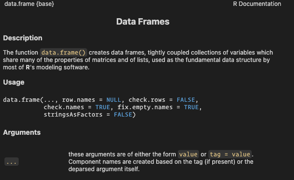

## Understanding error messages

```r
dat = data.frame(a = c(1,2),
                 b = c(3,4))
data[1]
```

```
Error in data[1]: object of type 'closure' is not subsettable
```

!?!?

```r
typeof(data)
```

```
[1] "closure"
```

```r
typeof(dat)
```

```
[1] "list"
```

Learning to read error messages will help you find coding errors.

Talk on this famous error: https://posit.co/resources/videos/object-of-type-closure-is-not-subsettable/

## Understand the objects you are working with

Print the object in the terminal:

```r
dat
```

```
  a b
1 1 3
2 2 4
```

- `View()` is useful for larger objects, try `View(mtcars)`
- `str()` gives you the structure of the object
- `pillar::glimpse()` is a nice alternative to `str()`
- For functions, printing can<sup>1</sup> give you the code. Try printing `data`.
[^1]: R functions can include compiled C++ code which will not be visible this way. Their dispatch can also vary depending on the supplied object class, we will get back to this later.

## Debugging basics

- Debugging is really useful for finding and fixing errors
- Use `browser()` to enter the debugger at a certain place

```r
return_largest_number = function(v1, v2) {
  browser()
  max(v1, -v2)
}
```

- VS Code has an `R debugger` extension that makes this easier

# Logic

- Introduction
- Basic R syntax
- When things don’t work
- Logic
- Subsetting
- Scoping
- Iteration

## Logic

We often want to run operations *conditional* or certain criteria. For this we need *logical operators*.

```r
1 == 2
```

```
[1] FALSE
```

```r
1 < 2
```

```
[1] TRUE
```

```r
1 == 2 & 1 < 2
```

```
[1] FALSE
```

```r
1 == 2 | 1 < 2
```

```
[1] TRUE
```

Note the difference between assignment (`=`) and comparison (`==`).

## Precedence

Let’s say we want to check if a variable is larger than two other variables:

```r
x = 3; y = 1; z = 4
x > y & z
```

```
[1] TRUE
```

Logical operators (`>`, `==`, etc) are evaluated before Boolean (`&` and `|`).

```r
3 > 1
```

```
[1] TRUE
```

```r
TRUE & 4
```

```
[1] TRUE
```

Boolean operators require logical arguments. R runs `as.logical(4)` before the comparison. All non-zero numbers are coerced to `TRUE`, only `0` is `FALSE`.

To get it right we need to be explicit:

```r
x > 1 & x > 4
```

```
[1] FALSE
```

## Logic on vectors

```r
c(1,2,3) > 2
```

```
[1] FALSE FALSE  TRUE
```

```r
c(1,2,3) > c(0,1,2)
```

```
[1] TRUE TRUE TRUE
```

But! When the vectors are of different lenght, R “recycles” the shorter vector.

```r
c(1,2,3) > c(1,3)
```

```
Warning in c(1, 2, 3) > c(1, 3): longer object length is not a multiple of
shorter object length
```

```
[1] FALSE FALSE  TRUE
```

When one object is a multiple of the other, there is not even a warning.

```r
c(1,2,3) > c(0,1,2,3,4,5)
```

```
[1]  TRUE  TRUE  TRUE FALSE FALSE FALSE
```

Be careful!

## Boolean operators on vectors

The same is true for Boolean operators:

```r
c(TRUE, FALSE) | c(FALSE, TRUE)
```

```
[1] TRUE TRUE
```

```r
c(TRUE, FALSE) & c(TRUE, FALSE, FALSE)
```

```
[1]  TRUE FALSE FALSE
```

To require scalars for our comparison, we can use `&&` and `||` instead:

```r
c(TRUE, FALSE) && c(FALSE, TRUE)
```

```
Error in c(TRUE, FALSE) && c(FALSE, TRUE): 'length = 2' in coercion to 'logical(1)'
```

## Missing values

In R, `NA` are properly treated as “missing”, the value could be anything.

```r
NA > 0
```

```
[1] NA
```

```r
NA & TRUE
```

```
[1] NA
```

But:

```r
NA | TRUE
```

```
[1] TRUE
```

```r
NA & FALSE
```

```
[1] FALSE
```

Here, it does not matter what `NA` could be, since both `TRUE | TRUE` and `FALSE | TRUE` evalute to `TRUE`.

## Missing values (cont.)

What if we want to check what values of a vector are missing:

```r
x = c(1, NA, 3)
x == NA
```

```
[1] NA NA NA
```

Actually, even `NA` is not equal to `NA`.

```r
NA == NA
```

```
[1] NA
```

Instead we need to use `is.na()`

```r
is.na(x)
```

```
[1] FALSE  TRUE FALSE
```

## Negation

`!` negates a logical statement:

```r
!TRUE
```

```
[1] FALSE
```

```r
1 != 2
```

```
[1] TRUE
```

```r
!(1 < 3)
```

```
[1] FALSE
```

For example we might want to filter for non-missing by running `!is.na()`:

```r
!is.na(x)
```

```
[1]  TRUE FALSE  TRUE
```

## %in%

To check if a scalar is an element of a vector:

```r
1 %in% c(1,2,3)
```

```
[1] TRUE
```

Works just as well on character vectors

```r
c("a", "c") %in% c("a", "b", "c")
```

```
[1] TRUE TRUE
```

For more on logical operators see the [R manual](https://stat.ethz.ch/R-manual/R-devel/library/base/html/Logic.html) and [Advanced R](https://adv-r.hadley.nz/control-flow.html).

## Caution: floating-point numbers

Arithmetic operations on floating points are **not exact**:

```r
0.3 == 0.3
```

```
[1] TRUE
```

```r
0.1 + 0.2 == 0.3
```

```
[1] FALSE
```

Instead do:

```r
all.equal(0.3, 0.1 + 0.2)
```

```
[1] TRUE
```

```r
abs(0.3 - (0.1 + 0.2)) < 1e-15
```

```
[1] TRUE
```

This is a general problem with floating points, not only in R. [Read more here](https://floating-point-gui.de/basic/). Make it a habit to never test floating points for equality (`==`, `<=`, `<=`), or you will run into nasty bugs sooner or later.

## Control flow: if/else

```r
if (1 == 3) "foo" else "bar"
```

```
[1] "bar"
```

Can be used directly in assignment (not recommended)

```r
x = 0 + if (1 == 3) 2 else 0
x
```

```
[1] 0
```

If statements should normally be written on multiple rows with brackets:

```r
if (TRUE) {
  "foo"
} else {
  "bar"
}
```

```
[1] "foo"
```

## Control flow: vectors

`if` can only evaluate logical scalars, for vectors, use `ifelse()`

```r
if (c(3,1) == c(1,4)) "foo" else "bar"
```

```
Error in if (c(3, 1) == c(1, 4)) "foo" else "bar": the condition has length > 1
```

```r
ifelse(c(3,1) == 1, "foo", "bar")
```

```
[1] "bar" "foo"
```

We can nest multiple `ifelse()`:

```r
x <- c(1,2,3)
ifelse(x==1, "a", ifelse(x==2, "b", NA))
```

```
[1] "a" "b" NA
```

Or use `data.table::fcase()` (or `dplyr::case_when()`)

```r
data.table::fcase(
  x == 1, "a",
  x == 2, "b"
)
```

```
[1] "a" "b" NA
```

# Subsetting

- Introduction
- Basic R syntax
- When things don’t work
- Logic
- Subsetting
- Scoping
- Iteration

## Subsetting with `[]`

```r
a = c(4,5,8,1)
```

`a[n]` selects the n:th element of the vector `a`

```r
a[2]
```

```
[1] 5
```

We can supply integers:

```r
a[c(1,3,1)]
```

```
[1] 4 8 4
```

```r
a[-3]
```

```
[1] 4 5 1
```

Or logicals:

```r
a[a > 4]
```

```
[1] 5 8
```

NB: In Python, indexing begins at 0 rather than 1!

## Selecting with `[[]]` or `$`

```r
a_list = list(named_elem = c(1,2,3),
               c("a", "b", "c"))
a_list
```

```
$named_elem
[1] 1 2 3

[[2]]
[1] "a" "b" "c"
```

Let’s pick the first element of the list:

```r
a_list[1]
```

```
$named_elem
[1] 1 2 3
```

```r
a_list[[1]]
```

```
[1] 1 2 3
```

Do you see the difference? `[]` returns a list of length 1 while `[[]]` returns the vector stored as the first element of `a_list` (try `typeof()` to see).

## Selecting with `[[]]` or `$` (cont.)

`a$x` is a shorthand for `a[["x"]]`

```r
a_list$named_elem
```

```
[1] 1 2 3
```

When `[[]]` returns a vector we can simply follow with `[]` to select specific vector element(s):

```r
a_list[[2]][1]
```

```
[1] "a"
```

```r
a_list$named_elem[3]
```

```
[1] 3
```

# Scoping

- Introduction
- Basic R syntax
- When things don’t work
- Logic
- Subsetting
- Scoping
- Iteration

## Function scope

Variables defined in functions are not “global”

```r
x = 10
set_xy = function() {
  x = 20
  y = 30
  c(x,y)
}
```

```r
set_xy()
```

```
[1] 20 30
```

```r
x
```

```
[1] 10
```

```r
y
```

```
Error: object 'y' not found
```

## Lexical scoping

But what if the object does not exist in the function scope?

```r
x = 10
y = 20
set_xy = function() {
  x = 20
  c(x, y)
}
set_xy()
```

```
[1] 20 20
```

R looks “one level up”

## Accessing data.frame columns

Let’s say we want to run a regression on the data in the `df` data.frame we created

```r
df
```

```
  x y
1 1 4
2 2 5
3 3 6
```

```r
lm(y ~ x)
```

```
Error in eval(predvars, data, env): object 'y' not found
```

R cannot find the `y` variable. We need to look “inside” the `df` object.

## Accessing data.frame columns (cont.)

We can supply each vector separately

```r
lm(df$y ~ df$x)
```

…or we can use `with()` to call `lm()` “inside” `df`:

```r
with(df, lm(y ~ x))
```

…or we can use the `data` argument of `lm()`

```r
lm(y ~ x, data = df) # check ?lm for all arguments
```

## Packages

- Packages are R extensions that can be really useful
- Installed with `install.packages()` and loaded with `library()`

[figure not shown]

```r
library(memer)
meme_get("OprahGiveaway") |>
  meme_text_bottom("EVERYONE GETS AN A",
                   size = 36)
```

## Packages (cont.)

- `library()` loads package functions into global environment
- Call package functions that are not loaded with `::`

```r
plt()
```

```
Error in plt(): could not find function "plt"
```

```r
tinyplot::plt(
  Sepal.Length ~ Petal.Length | Species,
  data = iris
)
```

[figure not shown]

## Methods

Lets try to look at the source code for the `mean()` function

```r
mean
```

```
function (x, ...)
UseMethod("mean")
<bytecode: 0x12ed161b0>
<environment: namespace:base>
```

`mean()` calls different *methods* depending on object *class*

```r
methods(mean)
```

```
[1] mean.Date        mean.default     mean.difftime    mean.IDate*
[5] mean.ITime*      mean.POSIXct     mean.POSIXlt     mean.quosure*
[9] mean.vctrs_vctr*
see '?methods' for accessing help and source code
```

```r
mean(c(1,2,3,4))
```

```
[1] 2.5
```

```r
mean(as.Date(c("2024-01-01",
               "2025-01-01")))
```

```
[1] "2024-07-02"
```

# Iteration

- Introduction
- Basic R syntax
- When things don’t work
- Logic
- Subsetting
- Scoping
- Iteration

## Loops

We often want to repeat the same operation many times.

Loops are good when each iteration is somehow dependent on the results of the previous.

```r
v <- c("foo", "bar", "foofoo", "barbar")
```

```r
for (i in 1:4) print(v[i])
```

```
[1] "foo"
[1] "bar"
[1] "foofoo"
[1] "barbar"
```

```r
for (i in v) print(i)
```

```
[1] "foo"
[1] "bar"
[1] "foofoo"
[1] "barbar"
```

## Vectorized operations

Before you write a loop, ask: Do I really need to iterate? Vectorized operations are often **much faster**.

You might have noticed we can do things like:

```r
1 + c(3,4)
```

```
[1] 4 5
```

This command runs `` `+`(1, 3) `` and `` `+`(1, 4) ``, i.e. it operates on both elements of the vector.

## Vectorized operations (cont.)

Similarly, we can *apply* any arbitrary function to each element:

```r
sapply(c(1,2,3), FUN = function(x) paste0(x, "^2=", x^2))
```

```
[1] "1^2=1" "2^2=4" "3^2=9"
```

There are three versions:

- `apply` for matrices
- `lapply` for vectors and lists
- `sapply` which is just `lapply(..., simplify = TRUE)`

The `parallel` package provides corresponding multi-core operations.

## Next lecture: Visualization